# Statistical Exploration of Tranmission Type on Miles Per Gallon

Shaun

April 10, 2017

# Executive Summary

This analysis was conducted on the mtcars dataset. The dataset was extracted from the 1974 Motor Trend US magazine and comprises of 32 automobiles between 1973 and 1974. The purpose of this analysis is to determine:  
* “Is an automatic or manual transmission better for MPG”  
* “Quantify the MPG difference between automatic and manual transmissions”

# Data Exploration

The dataset mtcars consists of the following information:  
A data frame with 32 observations on 11 variables.

[, 1] mpg Miles/(US) gallon  
[, 2] cyl Number of cylinders  
[, 3] disp Displacement (cu.in.)  
[, 4] hp Gross horsepower  
[, 5] drat Rear axle ratio  
[, 6] wt Weight (1000 lbs)  
[, 7] qsec 1/4 mile time  
[, 8] vs V/S  
[, 9] am Transmission (0 = automatic, 1 = manual)  
[,10] gear Number of forward gears  
[,11] carb Number of carburetors

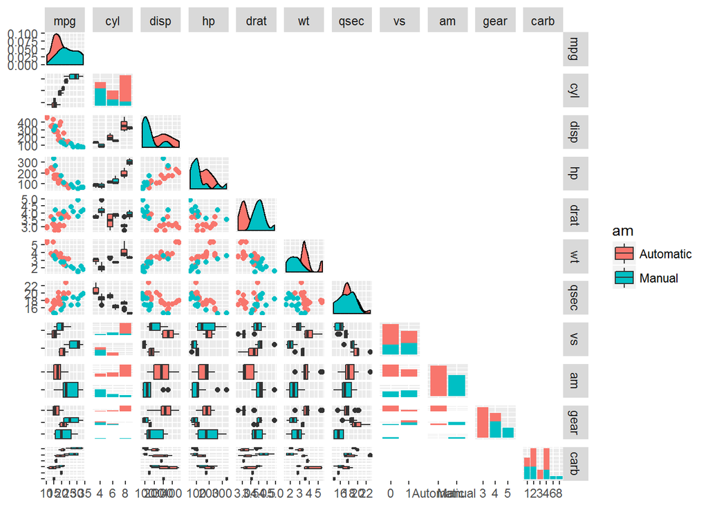

```r
# Loading the required libraries
suppressMessages(library(datasets))
suppressMessages(library(ggplot2))
suppressMessages(library(GGally))

# Loading the 'mtcars' dataset from the datasets library
data("mtcars")

# Convert the following columns to type factor
mtcars$cyl <- as.factor(mtcars$cyl)
mtcars$vs <- as.factor(mtcars$vs)
mtcars$gear <- as.factor(mtcars$gear)
mtcars$carb <- as.factor(mtcars$carb)
mtcars$am <- factor(mtcars$am,labels=c('Automatic','Manual'))

ggpairs(mtcars, ggplot2::aes(colour = am), legend = c(2,1),
  lower = list(
    continous = "smooth",
    combo =  "box",
    discrete = "facetbar"
  ),
  diag = list(
    continous = "densityDiag",
    discrete = "barDiag"
  ),
  upper = "blank"
)
```

From the pairs plot above, we can observe a few trends which will be investigated further:  
1. The boxplot of MPG ~ am seems to indicate a significant difference  
2. Manual transmission tend to cluster towards the higher end of MPG  
3. There appears to be relationships between the independant variables which may imply that there may be covariance

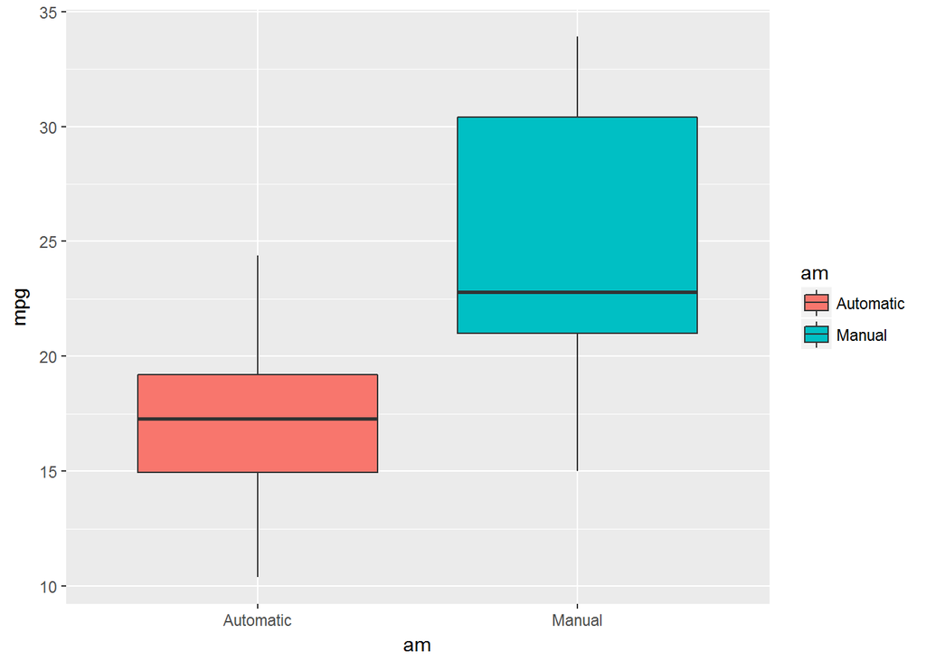

```r
ggplot(mtcars, aes(am, mpg))+
  geom_boxplot(aes(fill=am))
```

```r
ttest <- t.test(mpg ~ am, mtcars)
print(ttest)
```

```
##
##  Welch Two Sample t-test
##
## data:  mpg by am
## t = -3.7671, df = 18.332, p-value = 0.001374
## alternative hypothesis: true difference in means is not equal to 0
## 95 percent confidence interval:
##  -11.280194  -3.209684
## sample estimates:
## mean in group Automatic    mean in group Manual
##                17.14737                24.39231
```

From the t test above, P = 0.0013736 < 0.05 which implies that their mean difference is not equal to 0 so we can reject the null hypothesis. There is a significant difference between manual and automatic transmissions.

However, we need to investigate it further to understand how much of the variance in MPG is accounted for by the transmission type.

## Summary by transmission type

### Manual

```r
man<- mtcars[mtcars$am == "Manual",]
summary(man)
```

```
##       mpg        cyl        disp             hp             drat
##  Min.   :15.00   4:8   Min.   : 71.1   Min.   : 52.0   Min.   :3.54
##  1st Qu.:21.00   6:3   1st Qu.: 79.0   1st Qu.: 66.0   1st Qu.:3.85
##  Median :22.80   8:2   Median :120.3   Median :109.0   Median :4.08
##  Mean   :24.39         Mean   :143.5   Mean   :126.8   Mean   :4.05
##  3rd Qu.:30.40         3rd Qu.:160.0   3rd Qu.:113.0   3rd Qu.:4.22
##  Max.   :33.90         Max.   :351.0   Max.   :335.0   Max.   :4.93
##        wt             qsec       vs            am     gear  carb
##  Min.   :1.513   Min.   :14.50   0:6   Automatic: 0   3:0   1:4
##  1st Qu.:1.935   1st Qu.:16.46   1:7   Manual   :13   4:8   2:4
##  Median :2.320   Median :17.02                        5:5   3:0
##  Mean   :2.411   Mean   :17.36                              4:3
##  3rd Qu.:2.780   3rd Qu.:18.61                              6:1
##  Max.   :3.570   Max.   :19.90                              8:1
```

### Automatic

```r
auto<- mtcars[mtcars$am == "Automatic",]
summary(auto)
```

```
##       mpg        cyl         disp             hp             drat
##  Min.   :10.40   4: 3   Min.   :120.1   Min.   : 62.0   Min.   :2.760
##  1st Qu.:14.95   6: 4   1st Qu.:196.3   1st Qu.:116.5   1st Qu.:3.070
##  Median :17.30   8:12   Median :275.8   Median :175.0   Median :3.150
##  Mean   :17.15          Mean   :290.4   Mean   :160.3   Mean   :3.286
##  3rd Qu.:19.20          3rd Qu.:360.0   3rd Qu.:192.5   3rd Qu.:3.695
##  Max.   :24.40          Max.   :472.0   Max.   :245.0   Max.   :3.920
##        wt             qsec       vs             am     gear   carb
##  Min.   :2.465   Min.   :15.41   0:12   Automatic:19   3:15   1:3
##  1st Qu.:3.438   1st Qu.:17.18   1: 7   Manual   : 0   4: 4   2:6
##  Median :3.520   Median :17.82                         5: 0   3:3
##  Mean   :3.769   Mean   :18.18                                4:7
##  3rd Qu.:3.842   3rd Qu.:19.17                                6:0
##  Max.   :5.424   Max.   :22.90                                8:0
```

From the statistical summarise above, it appears that not only is the MPG for manual transmissions higher, their weight (wt), displacement (disp) and horsepower (hp) all appear to be on average lower than the automatic transmissions. It is also worth to note that the number of vehicles per cylinder class is very different as well. These factor may be confounding the results of transmission type on MPG.

# Models

```r
model1 <- lm(mpg~ am, mtcars)
summary(model1)
```

```
##
## Call:
## lm(formula = mpg ~ am, data = mtcars)
##
## Residuals:
##     Min      1Q  Median      3Q     Max
## -9.3923 -3.0923 -0.2974  3.2439  9.5077
##
## Coefficients:
##             Estimate Std. Error t value Pr(>|t|)
## (Intercept)   17.147      1.125  15.247 1.13e-15 ***
## amManual       7.245      1.764   4.106 0.000285 ***
## ---
## Signif. codes:  0 '***' 0.001 '**' 0.01 '*' 0.05 '.' 0.1 ' ' 1
##
## Residual standard error: 4.902 on 30 degrees of freedom
## Multiple R-squared:  0.3598, Adjusted R-squared:  0.3385
## F-statistic: 16.86 on 1 and 30 DF,  p-value: 0.000285
```

```r
model2 <- lm(mpg~ ., mtcars)
summary(model2)
```

```
##
## Call:
## lm(formula = mpg ~ ., data = mtcars)
##
## Residuals:
##     Min      1Q  Median      3Q     Max
## -3.5087 -1.3584 -0.0948  0.7745  4.6251
##
## Coefficients:
##             Estimate Std. Error t value Pr(>|t|)
## (Intercept) 23.87913   20.06582   1.190   0.2525
## cyl6        -2.64870    3.04089  -0.871   0.3975
## cyl8        -0.33616    7.15954  -0.047   0.9632
## disp         0.03555    0.03190   1.114   0.2827
## hp          -0.07051    0.03943  -1.788   0.0939 .
## drat         1.18283    2.48348   0.476   0.6407
## wt          -4.52978    2.53875  -1.784   0.0946 .
## qsec         0.36784    0.93540   0.393   0.6997
## vs1          1.93085    2.87126   0.672   0.5115
## amManual     1.21212    3.21355   0.377   0.7113
## gear4        1.11435    3.79952   0.293   0.7733
## gear5        2.52840    3.73636   0.677   0.5089
## carb2       -0.97935    2.31797  -0.423   0.6787
## carb3        2.99964    4.29355   0.699   0.4955
## carb4        1.09142    4.44962   0.245   0.8096
## carb6        4.47757    6.38406   0.701   0.4938
## carb8        7.25041    8.36057   0.867   0.3995
## ---
## Signif. codes:  0 '***' 0.001 '**' 0.01 '*' 0.05 '.' 0.1 ' ' 1
##
## Residual standard error: 2.833 on 15 degrees of freedom
## Multiple R-squared:  0.8931, Adjusted R-squared:  0.779
## F-statistic:  7.83 on 16 and 15 DF,  p-value: 0.000124
```

```r
model2 <- lm(mpg~ ., mtcars)
summary(model2)
```

[output not shown]

# Appendix

## Residual plots for model 1

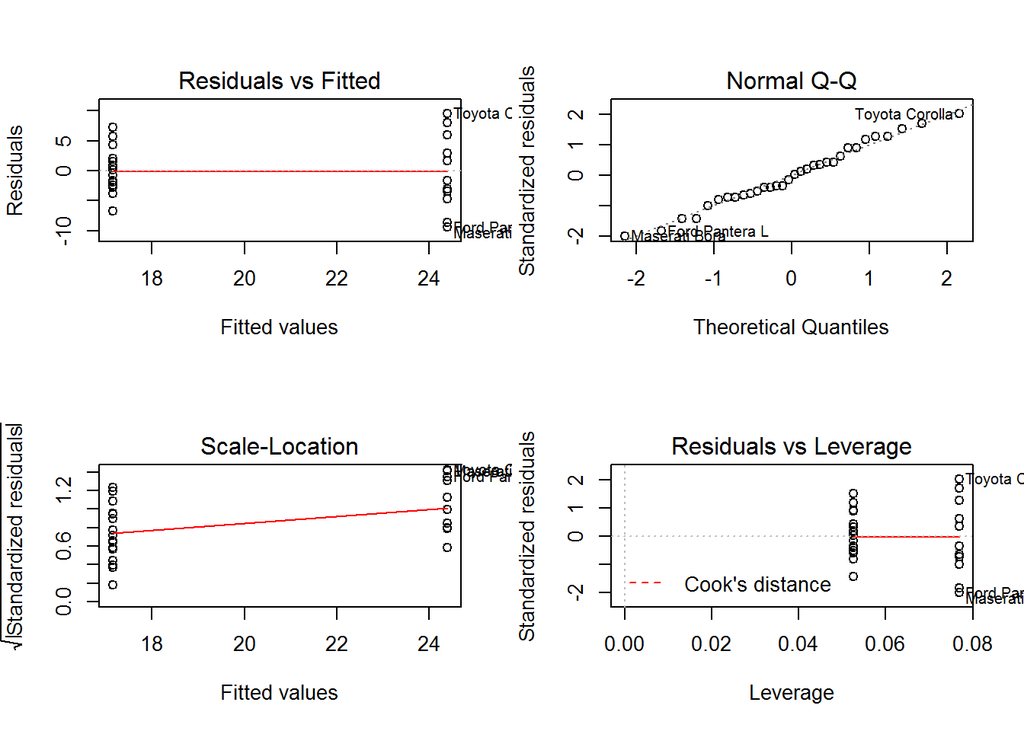

```r
par(mfrow =c(2,2))
plot(model1)
```

## Residual plots for model 2

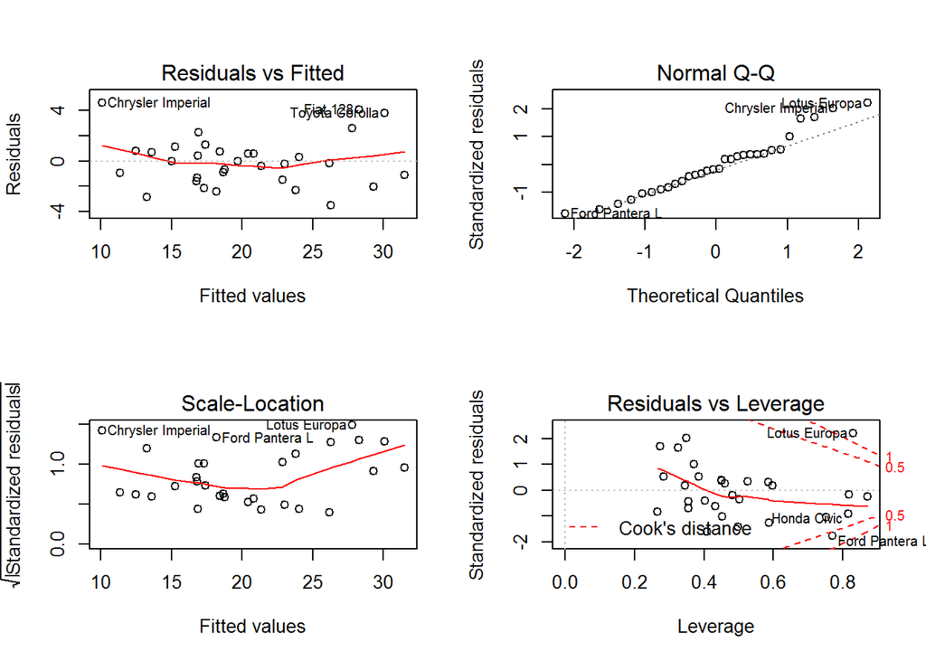

```r
par(mfrow =c(2,2))
plot(model2)
```